# MLP_鳶尾花多元分類

### 多層感知器

多層感知器（Multilayer Perceptron,縮寫MLP）是一種前向結構的人工神經網絡，映射一組輸入向量到一組輸出向量。MLP可以被看作是一個有向圖，由多個的節點層所組成，每一層都全連接到下一層。除了輸入節點，每個節點都是一個帶有非線性激活函數的神經元（或稱處理單元）。一種被稱為反向傳播算法的監督學習方法常被用來訓練MLP。

基本結構由三層組成：第一輸入層，中間隱藏層和最後輸出層，輸入元素和權重的乘積被饋給具有神經元偏差的求和結點,主要優勢在於其快速解決複雜問題的能力。

### 使用多層感知器實作鳶尾花多元分類

```python
from sklearn import datasets
import matplotlib.pyplot as plt
import tensorflow as tf
import pandas as pd
import numpy as np
import seaborn as sns
```

##### 讀取Scikit-learn Iris 資料集

```python
iris = datasets.load_iris()
iris
```

```
{'data': array([[5.1, 3.5, 1.4, 0.2],
        [4.9, 3. , 1.4, 0.2],
        [4.7, 3.2, 1.3, 0.2],
        [4.6, 3.1, 1.5, 0.2],
        [5. , 3.6, 1.4, 0.2],
        [5.4, 3.9, 1.7, 0.4],
        [4.6, 3.4, 1.4, 0.3],
        [5. , 3.4, 1.5, 0.2],
        [4.4, 2.9, 1.4, 0.2],
        [4.9, 3.1, 1.5, 0.1],
        [5.4, 3.7, 1.5, 0.2],
        [4.8, 3.4, 1.6, 0.2],
        [4.8, 3. , 1.4, 0.1],
        [4.3, 3. , 1.1, 0.1],
        [5.8, 4. , 1.2, 0.2],
        [5.7, 4.4, 1.5, 0.4],
        [5.4, 3.9, 1.3, 0.4],
        [5.1, 3.5, 1.4, 0.3],
        [5.7, 3.8, 1.7, 0.3],
        [5.1, 3.8, 1.5, 0.3],
        [5.4, 3.4, 1.7, 0.2],
        [5.1, 3.7, 1.5, 0.4],
        [4.6, 3.6, 1. , 0.2],
        [5.1, 3.3, 1.7, 0.5],
        [4.8, 3.4, 1.9, 0.2],
        [5. , 3. , 1.6, 0.2],
        [5. , 3.4, 1.6, 0.4],
        [5.2, 3.5, 1.5, 0.2],
        [5.2, 3.4, 1.4, 0.2],
        [4.7, 3.2, 1.6, 0.2],
        [4.8, 3.1, 1.6, 0.2],
        [5.4, 3.4, 1.5, 0.4],
        [5.2, 4.1, 1.5, 0.1],
        [5.5, 4.2, 1.4, 0.2],
        [4.9, 3.1, 1.5, 0.2],
        [5. , 3.2, 1.2, 0.2],
        [5.5, 3.5, 1.3, 0.2],
        [4.9, 3.6, 1.4, 0.1],
        [4.4, 3. , 1.3, 0.2],
        [5.1, 3.4, 1.5, 0.2],
```

[output cut: 110 more lines]

```
 'target': array([0, 0, 0, 0, 0, 0, 0, 0, 0, 0, 0, 0, 0, 0, 0, 0, 0, 0, 0, 0, 0, 0,
        0, 0, 0, 0, 0, 0, 0, 0, 0, 0, 0, 0, 0, 0, 0, 0, 0, 0, 0, 0, 0, 0,
        0, 0, 0, 0, 0, 0, 1, 1, 1, 1, 1, 1, 1, 1, 1, 1, 1, 1, 1, 1, 1, 1,
        1, 1, 1, 1, 1, 1, 1, 1, 1, 1, 1, 1, 1, 1, 1, 1, 1, 1, 1, 1, 1, 1,
        1, 1, 1, 1, 1, 1, 1, 1, 1, 1, 1, 1, 2, 2, 2, 2, 2, 2, 2, 2, 2, 2,
        2, 2, 2, 2, 2, 2, 2, 2, 2, 2, 2, 2, 2, 2, 2, 2, 2, 2, 2, 2, 2, 2,
        2, 2, 2, 2, 2, 2, 2, 2, 2, 2, 2, 2, 2, 2, 2, 2, 2, 2]),
 'frame': None,
 'target_names': array(['setosa', 'versicolor', 'virginica'], dtype='<U10'),
 'DESCR': '.. _iris_dataset:\n\nIris plants dataset\n--------------------\n\n**Data Set Characteristics:**\n\n    :Number of Instances: 150 (50 in each of three classes)\n    :Number of Attributes: 4 numeric, predictive attributes and the class\n    :Attribute Information:\n        - sepal length in…
 'feature_names': ['sepal length (cm)',
  'sepal width (cm)',
  'petal length (cm)',
  'petal width (cm)'],
 'filename': 'd:\\anaconda\\envs\\tensorflow\\lib\\site-packages\\sklearn\\datasets\\data\\iris.csv'}
```

##### 將sctkit-learn資料集轉為Pandas資料集

```python
data = pd.DataFrame(data= np.c_[iris['data'], iris['target']],
                     columns= iris['feature_names'] + ['target'])

data = data.rename(columns={'sepal width (cm)': 'sepal_width','sepal length (cm)':'sepal_length','petal length (cm)':'petal_length','petal width (cm)':'petal_width' })
data['target'] = data['target'].astype(int)
data
```

|  | sepal_length | sepal_width | petal_length | petal_width | target |
| --- | --- | --- | --- | --- | --- |
| 0 | 5.1 | 3.5 | 1.4 | 0.2 | 0 |
| 1 | 4.9 | 3.0 | 1.4 | 0.2 | 0 |
| 2 | 4.7 | 3.2 | 1.3 | 0.2 | 0 |
| 3 | 4.6 | 3.1 | 1.5 | 0.2 | 0 |
| 4 | 5.0 | 3.6 | 1.4 | 0.2 | 0 |
| ... | ... | ... | ... | ... | ... |
| 145 | 6.7 | 3.0 | 5.2 | 2.3 | 2 |
| 146 | 6.3 | 2.5 | 5.0 | 1.9 | 2 |
| 147 | 6.5 | 3.0 | 5.2 | 2.0 | 2 |
| 148 | 6.2 | 3.4 | 5.4 | 2.3 | 2 |
| 149 | 5.9 | 3.0 | 5.1 | 1.8 | 2 |

150 rows × 5 columns

##### 首先進行資料及敘述性統計分析,了解資料分佈概況

```python
data.describe()
```

|  | sepal_length | sepal_width | petal_length | petal_width | target |
| --- | --- | --- | --- | --- | --- |
| count | 150.000000 | 150.000000 | 150.000000 | 150.000000 | 150.000000 |
| mean | 5.843333 | 3.057333 | 3.758000 | 1.199333 | 1.000000 |
| std | 0.828066 | 0.435866 | 1.765298 | 0.762238 | 0.819232 |
| min | 4.300000 | 2.000000 | 1.000000 | 0.100000 | 0.000000 |
| 25% | 5.100000 | 2.800000 | 1.600000 | 0.300000 | 0.000000 |
| 50% | 5.800000 | 3.000000 | 4.350000 | 1.300000 | 1.000000 |
| 75% | 6.400000 | 3.300000 | 5.100000 | 1.800000 | 2.000000 |
| max | 7.900000 | 4.400000 | 6.900000 | 2.500000 | 2.000000 |

```python
data.head
```

```
<bound method NDFrame.head of      sepal_length  sepal_width  petal_length  petal_width  target
0             5.1          3.5           1.4          0.2       0
1             4.9          3.0           1.4          0.2       0
2             4.7          3.2           1.3          0.2       0
3             4.6          3.1           1.5          0.2       0
4             5.0          3.6           1.4          0.2       0
..            ...          ...           ...          ...     ...
145           6.7          3.0           5.2          2.3       2
146           6.3          2.5           5.0          1.9       2
147           6.5          3.0           5.2          2.0       2
148           6.2          3.4           5.4          2.3       2
149           5.9          3.0           5.1          1.8       2

[150 rows x 5 columns]>
```

##### 將資料視覺化呈現分佈情況

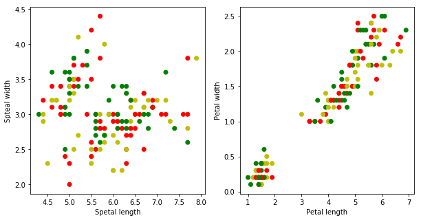

```python
colmap = np.array(["r","g","y"])
plt.figure(figsize=(10,5))
plt.subplot(1,2,1)
plt.subplots_adjust(hspace = 0.5)
plt.scatter(data['sepal_length'],data['sepal_width'],c=colmap)
plt.xlabel('Spetal length')
plt.ylabel('Spteal width')

plt.subplot(1,2,2)
plt.subplots_adjust(hspace = 0.5)
plt.scatter(data['petal_length'],data['petal_width'],c=colmap)
plt.xlabel('Petal length')
plt.ylabel('Petal width')

plt.show()
```

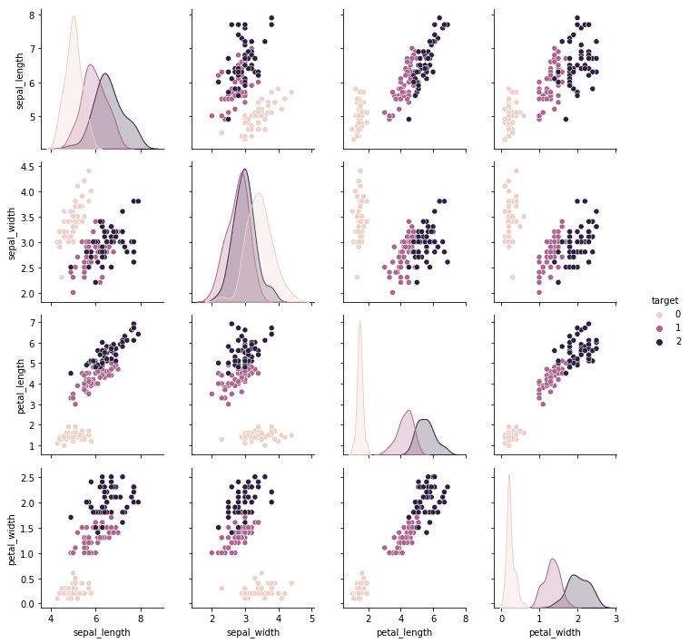

```python
sns.pairplot(data,hue="target")
```

##### 先使用random.shuffle()將資料亂數打亂, 然後進行one_hot編碼

```python
dataset= data.values
np.random.shuffle(dataset)
X = dataset[:,0:4].astype(float)
Y = tf.keras.utils.to_categorical(dataset[:,4])
```

```python
X
```

```
array([[6.3, 3.3, 4.7, 1.6],
       [5. , 3.6, 1.4, 0.2],
       [6.5, 3.2, 5.1, 2. ],
       [7.2, 3.6, 6.1, 2.5],
       [5.8, 2.6, 4. , 1.2],
       [6.3, 3.4, 5.6, 2.4],
       [6.4, 2.8, 5.6, 2.2],
       [6.5, 3. , 5.8, 2.2],
       [5.1, 3.8, 1.6, 0.2],
       [4.9, 2.4, 3.3, 1. ],
       [7.9, 3.8, 6.4, 2. ],
       [5.7, 3. , 4.2, 1.2],
       [5.5, 2.4, 3.8, 1.1],
       [5.8, 2.7, 3.9, 1.2],
       [6. , 3. , 4.8, 1.8],
       [4.9, 3.1, 1.5, 0.1],
       [6.2, 2.2, 4.5, 1.5],
       [5.9, 3. , 4.2, 1.5],
       [7.1, 3. , 5.9, 2.1],
       [6.7, 3.3, 5.7, 2.1],
       [5.5, 2.5, 4. , 1.3],
       [5.8, 2.8, 5.1, 2.4],
       [6.1, 2.8, 4. , 1.3],
       [5.6, 3. , 4.1, 1.3],
       [6.2, 2.9, 4.3, 1.3],
       [7.6, 3. , 6.6, 2.1],
       [4.9, 2.5, 4.5, 1.7],
       [5.3, 3.7, 1.5, 0.2],
       [4.3, 3. , 1.1, 0.1],
       [5.7, 2.6, 3.5, 1. ],
       [4.8, 3.4, 1.6, 0.2],
       [6.8, 2.8, 4.8, 1.4],
       [5.8, 4. , 1.2, 0.2],
       [6. , 2.2, 4. , 1. ],
       [5.7, 2.5, 5. , 2. ],
       [5.5, 3.5, 1.3, 0.2],
       [5.7, 4.4, 1.5, 0.4],
       [6.4, 2.7, 5.3, 1.9],
       [5. , 2.3, 3.3, 1. ],
       [6.7, 3.3, 5.7, 2.5],
```

[output cut: 95 more lines]

```
       [4.8, 3. , 1.4, 0.1],
       [5.6, 2.7, 4.2, 1.3],
       [6.4, 2.8, 5.6, 2.1],
       [6.1, 3. , 4.6, 1.4],
       [5.7, 3.8, 1.7, 0.3],
       [7. , 3.2, 4.7, 1.4],
       [5.1, 3.7, 1.5, 0.4],
       [6.9, 3.1, 5.4, 2.1],
       [7.2, 3.2, 6. , 1.8],
       [6.4, 3.1, 5.5, 1.8],
       [5. , 3.5, 1.3, 0.3],
       [5.4, 3.9, 1.3, 0.4],
       [6.3, 3.3, 6. , 2.5],
       [6. , 3.4, 4.5, 1.6],
       [6.8, 3. , 5.5, 2.1]])
```

```python
Y
```

```
array([[0., 1., 0.],
       [1., 0., 0.],
       [0., 0., 1.],
       [0., 0., 1.],
       [0., 1., 0.],
       [0., 0., 1.],
       [0., 0., 1.],
       [0., 0., 1.],
       [1., 0., 0.],
       [0., 1., 0.],
       [0., 0., 1.],
       [0., 1., 0.],
       [0., 1., 0.],
       [0., 1., 0.],
       [0., 0., 1.],
       [1., 0., 0.],
       [0., 1., 0.],
       [0., 1., 0.],
       [0., 0., 1.],
       [0., 0., 1.],
       [0., 1., 0.],
       [0., 0., 1.],
       [0., 1., 0.],
       [0., 1., 0.],
       [0., 1., 0.],
       [0., 0., 1.],
       [0., 0., 1.],
       [1., 0., 0.],
       [1., 0., 0.],
       [0., 1., 0.],
       [1., 0., 0.],
       [0., 1., 0.],
       [1., 0., 0.],
       [0., 1., 0.],
       [0., 0., 1.],
       [1., 0., 0.],
       [1., 0., 0.],
       [0., 0., 1.],
       [0., 1., 0.],
       [0., 0., 1.],
```

[output cut: 95 more lines]

```
       [1., 0., 0.],
       [0., 1., 0.],
       [0., 0., 1.],
       [0., 1., 0.],
       [1., 0., 0.],
       [0., 1., 0.],
       [1., 0., 0.],
       [0., 0., 1.],
       [0., 0., 1.],
       [0., 0., 1.],
       [1., 0., 0.],
       [1., 0., 0.],
       [0., 0., 1.],
       [0., 1., 0.],
       [0., 0., 1.]], dtype=float32)
```

##### 進行資料數值標準化

公式 : (X-X_Mean) / X_Std

```python
X -= X.mean(axis=0)
X /= X.std(axis=0)
```

##### 將資料訓練及集測試集

```python
X_train, Y_train = X[:120],Y[:120]
X_test, Y_test = X[120:],Y[120:]
```

```python
X_train
```

```
array([[ 5.53333275e-01,  5.58610819e-01,  5.35408562e-01,
         5.27406285e-01],
       [-1.02184904e+00,  1.24920112e+00, -1.34022653e+00,
        -1.31544430e+00],
       [ 7.95669016e-01,  3.28414053e-01,  7.62758269e-01,
         1.05393502e+00],
       [ 1.64384411e+00,  1.24920112e+00,  1.33113254e+00,
         1.71209594e+00],
       [-5.25060772e-02, -1.05276654e+00,  1.37546573e-01,
         8.77547895e-04],
       [ 5.53333275e-01,  7.88807586e-01,  1.04694540e+00,
         1.58046376e+00],
       [ 6.74501145e-01, -5.92373012e-01,  1.04694540e+00,
         1.31719939e+00],
       [ 7.95669016e-01, -1.31979479e-01,  1.16062026e+00,
         1.31719939e+00],
       [-9.00681170e-01,  1.70959465e+00, -1.22655167e+00,
        -1.31544430e+00],
       [-1.14301691e+00, -1.51316008e+00, -2.60315415e-01,
        -2.62386821e-01],
       [ 2.49201920e+00,  1.70959465e+00,  1.50164482e+00,
         1.05393502e+00],
       [-1.73673948e-01, -1.31979479e-01,  2.51221427e-01,
         8.77547895e-04],
       [-4.16009689e-01, -1.51316008e+00,  2.38717193e-02,
        -1.30754636e-01],
       [-5.25060772e-02, -8.22569778e-01,  8.07091462e-02,
         8.77547895e-04],
       [ 1.89829664e-01, -1.31979479e-01,  5.92245988e-01,
         7.90670654e-01],
       [-1.14301691e+00,  9.82172869e-02, -1.28338910e+00,
        -1.44707648e+00],
       [ 4.32165405e-01, -1.97355361e+00,  4.21733708e-01,
         3.95774101e-01],
       [ 6.86617933e-02, -1.31979479e-01,  2.51221427e-01,
         3.95774101e-01],
       [ 1.52267624e+00, -1.31979479e-01,  1.21745768e+00,
         1.18556721e+00],
       [ 1.03800476e+00,  5.58610819e-01,  1.10378283e+00,
         1.18556721e+00],
```

[output cut: 185 more lines]

```
        -1.18381211e+00],
       [ 2.24968346e+00, -5.92373012e-01,  1.67215710e+00,
         1.05393502e+00],
       [ 1.89829664e-01, -1.97355361e+00,  7.05920842e-01,
         3.95774101e-01],
       [-2.94841818e-01, -3.62176246e-01, -8.98031345e-02,
         1.32509732e-01],
       [-2.94841818e-01, -5.92373012e-01,  6.49083415e-01,
         1.05393502e+00],
       [-7.79513300e-01,  7.88807586e-01, -1.34022653e+00,
        -1.31544430e+00],
       [-1.02184904e+00,  5.58610819e-01, -1.34022653e+00,
        -1.31544430e+00],
       [ 1.64384411e+00, -1.31979479e-01,  1.16062026e+00,
         5.27406285e-01]])
```

##### 模型定義

定義一個四層的神經網路:

- Input layer : 4 Features
- Hidden layer : 6 units
- Hidden layer : 6 units
- Output layer : 3

```python
model = tf.keras.models.Sequential()
```

```python
model.add(tf.keras.layers.Dense(6,input_shape=(4,),activation='relu'))
model.add(tf.keras.layers.Dense(6,activation='relu'))
model.add(tf.keras.layers.Dense(3,activation='softmax'))
```

```python
model.summary()
```

```
Model: "sequential_1"
_________________________________________________________________
Layer (type)                 Output Shape              Param #
=================================================================
dense_3 (Dense)              (None, 6)                 30
_________________________________________________________________
dense_4 (Dense)              (None, 6)                 42
_________________________________________________________________
dense_5 (Dense)              (None, 3)                 21
=================================================================
Total params: 93
Trainable params: 93
Non-trainable params: 0
_________________________________________________________________
```

Hidden layer1 : 4(features)6(units)+6 = 30  
Hidden layer2 : 66(units)+6 = 42  
Output layer : 6*3+3 = 21

##### 編譯模型

- 損失函數 : loss="categorical_crossentropy" => 多元分類使用
- 最佳化 : adam ＝＞替代傳統隨機梯度下降過程的一階優化算法，它能基於訓練數據疊代地更新神經網絡權重

```python
model.compile(loss="categorical_crossentropy",optimizer="adam",metrics=["accuracy"])
```

```python
model.fit(X_train,Y_train,epochs=100,batch_size=5)
```

```
Train on 120 samples
```

```
<tensorflow.python.keras.callbacks.History at 0x1a5761cf288>
```

##### 進行模型評估

```python
loss, accuracy = model.evaluate(X_test,Y_test)
```

```python
print("損失率:%.2f%%, 正確率:%.2f%%" %(loss*100,accuracy*100))
```

```
損失率:10.66%, 正確率:93.33%
```

##### 儲存模型

```python
model.save("Self_Model/iris.h5")
```

##### 預測花種類

```python
X_test
```

```
array([[-0.29484182, -0.13197948,  0.42173371,  0.3957741 ],
       [-0.90068117,  0.78880759, -1.2833891 , -1.3154443 ],
       [ 0.06866179,  0.32841405,  0.59224599,  0.79067065],
       [-0.17367395, -0.36217625,  0.25122143,  0.13250973],
       [-0.41600969,  2.63038172, -1.34022653, -1.3154443 ],
       [-0.29484182, -1.28296331,  0.08070915, -0.13075464],
       [-1.02184904,  0.78880759, -1.22655167, -1.05217993],
       [ 0.79566902, -0.59237301,  0.47857113,  0.3957741 ],
       [-1.02184904,  0.32841405, -1.45390138, -1.3154443 ],
       [-1.02184904, -0.13197948, -1.22655167, -1.3154443 ],
       [-1.38535265,  0.32841405, -1.39706395, -1.3154443 ],
       [ 0.55333328, -0.59237301,  0.76275827,  0.3957741 ],
       [ 1.15917263,  0.32841405,  1.21745768,  1.44883158],
       [-0.7795133 ,  2.40018495, -1.2833891 , -1.44707648],
       [ 0.67450115, -0.36217625,  0.30805885,  0.13250973],
       [-1.26418478, -0.13197948, -1.34022653, -1.44707648],
       [-0.29484182, -0.82256978,  0.25122143,  0.13250973],
       [ 0.67450115, -0.59237301,  1.0469454 ,  1.18556721],
       [ 0.31099753, -0.13197948,  0.47857113,  0.26414192],
       [-0.17367395,  1.70959465, -1.16971425, -1.18381211],
       [ 1.40150837,  0.32841405,  0.53540856,  0.26414192],
       [-0.90068117,  1.47939788, -1.2833891 , -1.05217993],
       [ 1.2803405 ,  0.09821729,  0.93327055,  1.18556721],
       [ 1.64384411,  0.32841405,  1.27429511,  0.79067065],
       [ 0.67450115,  0.09821729,  0.99010798,  0.79067065],
       [-1.02184904,  1.01900435, -1.39706395, -1.18381211],
       [-0.53717756,  1.93979142, -1.39706395, -1.05217993],
       [ 0.55333328,  0.55861082,  1.27429511,  1.71209594],
       [ 0.18982966,  0.78880759,  0.42173371,  0.52740629],
       [ 1.15917263, -0.13197948,  0.99010798,  1.18556721]])
```

```python
predition = model.predict_classes(X_test)
Y_target = dataset[:,4][120:].astype(int)
```

```python
print(predition)
print(Y_target)
```

```
[1 0 2 1 0 1 0 1 0 0 0 1 2 0 1 0 1 2 1 0 1 0 2 2 2 0 0 2 1 2]
[1 0 1 1 0 1 0 1 0 0 0 2 2 0 1 0 1 2 1 0 1 0 2 2 2 0 0 2 1 2]
```